# NYC RealEstate

Fredrick Jones, Jian Quan Chen, Tilon

2024-04-24

### What is the probability that a person will crash their car and also the amount of money it will cost if the person does crash their car?

```r
data_train <- read.csv('https://raw.githubusercontent.com/LeJQC/DATA-621-Group-2/main/HW4/insurance_training_data.csv')
data_eval <- read.csv('https://raw.githubusercontent.com/LeJQC/DATA-621-Group-2/main/HW4/insurance-evaluation-data.csv')
```

```r
head(data_train)
```

```
##   INDEX TARGET_FLAG TARGET_AMT KIDSDRIV AGE HOMEKIDS YOJ   INCOME PARENT1
## 1     1           0          0        0  60        0  11  $67,349      No
## 2     2           0          0        0  43        0  11  $91,449      No
## 3     4           0          0        0  35        1  10  $16,039      No
## 4     5           0          0        0  51        0  14               No
## 5     6           0          0        0  50        0  NA $114,986      No
## 6     7           1       2946        0  34        1  12 $125,301     Yes
##   HOME_VAL MSTATUS SEX     EDUCATION           JOB TRAVTIME    CAR_USE BLUEBOOK
## 1       $0    z_No   M           PhD  Professional       14    Private  $14,230
## 2 $257,252    z_No   M z_High School z_Blue Collar       22 Commercial  $14,940
## 3 $124,191     Yes z_F z_High School      Clerical        5    Private   $4,010
## 4 $306,251     Yes   M  <High School z_Blue Collar       32    Private  $15,440
## 5 $243,925     Yes z_F           PhD        Doctor       36    Private  $18,000
## 6       $0    z_No z_F     Bachelors z_Blue Collar       46 Commercial  $17,430
##   TIF   CAR_TYPE RED_CAR OLDCLAIM CLM_FREQ REVOKED MVR_PTS CAR_AGE
## 1  11    Minivan     yes   $4,461        2      No       3      18
## 2   1    Minivan     yes       $0        0      No       0       1
## 3   4      z_SUV      no  $38,690        2      No       3      10
## 4   7    Minivan     yes       $0        0      No       0       6
## 5   1      z_SUV      no  $19,217        2     Yes       3      17
## 6   1 Sports Car      no       $0        0      No       0       7
##            URBANICITY
## 1 Highly Urban/ Urban
## 2 Highly Urban/ Urban
## 3 Highly Urban/ Urban
## 4 Highly Urban/ Urban
## 5 Highly Urban/ Urban
## 6 Highly Urban/ Urban
```

### Data Exploration

```r
skim(data_train)
```

Data summary

| Name | data_train |
| --- | --- |
| Number of rows | 8161 |
| Number of columns | 26 |
| _______________________ |  |
| Column type frequency: |  |
| character | 14 |
| numeric | 12 |
| ________________________ |  |
| Group variables | None |

**Variable type: character**

| skim_variable | n_missing | complete_rate | min | max | empty | n_unique | whitespace |
| --- | --- | --- | --- | --- | --- | --- | --- |
| INCOME | 0 | 1 | 0 | 8 | 445 | 6613 | 0 |
| PARENT1 | 0 | 1 | 2 | 3 | 0 | 2 | 0 |
| HOME_VAL | 0 | 1 | 0 | 8 | 464 | 5107 | 0 |
| MSTATUS | 0 | 1 | 3 | 4 | 0 | 2 | 0 |
| SEX | 0 | 1 | 1 | 3 | 0 | 2 | 0 |
| EDUCATION | 0 | 1 | 3 | 13 | 0 | 5 | 0 |
| JOB | 0 | 1 | 0 | 13 | 526 | 9 | 0 |
| CAR_USE | 0 | 1 | 7 | 10 | 0 | 2 | 0 |
| BLUEBOOK | 0 | 1 | 6 | 7 | 0 | 2789 | 0 |
| CAR_TYPE | 0 | 1 | 3 | 11 | 0 | 6 | 0 |
| RED_CAR | 0 | 1 | 2 | 3 | 0 | 2 | 0 |
| OLDCLAIM | 0 | 1 | 2 | 7 | 0 | 2857 | 0 |
| REVOKED | 0 | 1 | 2 | 3 | 0 | 2 | 0 |
| URBANICITY | 0 | 1 | 19 | 21 | 0 | 2 | 0 |

**Variable type: numeric**

| skim_variable | n_missing | complete_rate | mean | sd | p0 | p25 | p50 | p75 | p100 | hist |
| --- | --- | --- | --- | --- | --- | --- | --- | --- | --- | --- |
| INDEX | 0 | 1.00 | 5151.87 | 2978.89 | 1 | 2559 | 5133 | 7745 | 10302.0 | ▇▇▇▇▇ |
| TARGET_FLAG | 0 | 1.00 | 0.26 | 0.44 | 0 | 0 | 0 | 1 | 1.0 | ▇▁▁▁▃ |
| TARGET_AMT | 0 | 1.00 | 1504.32 | 4704.03 | 0 | 0 | 0 | 1036 | 107586.1 | ▇▁▁▁▁ |
| KIDSDRIV | 0 | 1.00 | 0.17 | 0.51 | 0 | 0 | 0 | 0 | 4.0 | ▇▁▁▁▁ |
| AGE | 6 | 1.00 | 44.79 | 8.63 | 16 | 39 | 45 | 51 | 81.0 | ▁▆▇▂▁ |
| HOMEKIDS | 0 | 1.00 | 0.72 | 1.12 | 0 | 0 | 0 | 1 | 5.0 | ▇▂▁▁▁ |
| YOJ | 454 | 0.94 | 10.50 | 4.09 | 0 | 9 | 11 | 13 | 23.0 | ▂▃▇▃▁ |
| TRAVTIME | 0 | 1.00 | 33.49 | 15.91 | 5 | 22 | 33 | 44 | 142.0 | ▇▇▁▁▁ |
| TIF | 0 | 1.00 | 5.35 | 4.15 | 1 | 1 | 4 | 7 | 25.0 | ▇▆▁▁▁ |
| CLM_FREQ | 0 | 1.00 | 0.80 | 1.16 | 0 | 0 | 0 | 2 | 5.0 | ▇▂▁▁▁ |
| MVR_PTS | 0 | 1.00 | 1.70 | 2.15 | 0 | 0 | 1 | 3 | 13.0 | ▇▂▁▁▁ |
| CAR_AGE | 510 | 0.94 | 8.33 | 5.70 | -3 | 1 | 8 | 12 | 28.0 | ▆▇▇▃▁ |

From the table, we can see that there are 8161 rows and 26 columns in the dataset, two of which are response variables (TARGET_FLAG and TARGET_AMT). Also, we see that there are missing values within the CAR_AGE, AGE, and YOJ columns. In addition, there are 12 columns that are numeric variables and 14 columns that are made up of strings.

Using the glimpse() function, we can see that some of the 14 columns that are made of up string are actually continuous variables like OLDCLAIM, HOME_VAL, INCOME, and BLUEBOOK. We will need to do some data cleaning later on to convert these columns to numeric variables. Also, since some of the categorical variables have 2 characteristics, we can substitute these observations to 0 and 1 which will make it easier when we build our models. These are the categorical variables that are dichotomous: PARENT1, SEX, MSTATUS, CAR_USE, RED_CAR, REVOKED, URBANICITY.

```r
glimpse(data_train)
```

```
## Rows: 8,161
## Columns: 26
## $ INDEX       <int> 1, 2, 4, 5, 6, 7, 8, 11, 12, 13, 14, 15, 16, 17, 19, 20, 2…
## $ TARGET_FLAG <int> 0, 0, 0, 0, 0, 1, 0, 1, 1, 0, 1, 0, 0, 1, 1, 0, 0, 0, 0, 1…
## $ TARGET_AMT  <dbl> 0.000, 0.000, 0.000, 0.000, 0.000, 2946.000, 0.000, 4021.0…
## $ KIDSDRIV    <int> 0, 0, 0, 0, 0, 0, 0, 1, 0, 0, 0, 0, 0, 0, 0, 0, 0, 0, 0, 0…
## $ AGE         <int> 60, 43, 35, 51, 50, 34, 54, 37, 34, 50, 53, 43, 55, 53, 45…
## $ HOMEKIDS    <int> 0, 0, 1, 0, 0, 1, 0, 2, 0, 0, 0, 0, 0, 0, 0, 3, 0, 3, 2, 1…
## $ YOJ         <int> 11, 11, 10, 14, NA, 12, NA, NA, 10, 7, 14, 5, 11, 11, 0, 1…
## $ INCOME      <chr> "$67,349", "$91,449", "$16,039", "", "$114,986", "$125,301…
## $ PARENT1     <chr> "No", "No", "No", "No", "No", "Yes", "No", "No", "No", "No…
## $ HOME_VAL    <chr> "$0", "$257,252", "$124,191", "$306,251", "$243,925", "$0"…
## $ MSTATUS     <chr> "z_No", "z_No", "Yes", "Yes", "Yes", "z_No", "Yes", "Yes",…
## $ SEX         <chr> "M", "M", "z_F", "M", "z_F", "z_F", "z_F", "M", "z_F", "M"…
## $ EDUCATION   <chr> "PhD", "z_High School", "z_High School", "<High School", "…
## $ JOB         <chr> "Professional", "z_Blue Collar", "Clerical", "z_Blue Colla…
## $ TRAVTIME    <int> 14, 22, 5, 32, 36, 46, 33, 44, 34, 48, 15, 36, 25, 64, 48,…
## $ CAR_USE     <chr> "Private", "Commercial", "Private", "Private", "Private", …
## $ BLUEBOOK    <chr> "$14,230", "$14,940", "$4,010", "$15,440", "$18,000", "$17…
## $ TIF         <int> 11, 1, 4, 7, 1, 1, 1, 1, 1, 7, 1, 7, 7, 6, 1, 6, 6, 7, 4, …
## $ CAR_TYPE    <chr> "Minivan", "Minivan", "z_SUV", "Minivan", "z_SUV", "Sports…
## $ RED_CAR     <chr> "yes", "yes", "no", "yes", "no", "no", "no", "yes", "no", …
## $ OLDCLAIM    <chr> "$4,461", "$0", "$38,690", "$0", "$19,217", "$0", "$0", "$…
## $ CLM_FREQ    <int> 2, 0, 2, 0, 2, 0, 0, 1, 0, 0, 0, 0, 2, 0, 0, 0, 0, 0, 0, 2…
## $ REVOKED     <chr> "No", "No", "No", "No", "Yes", "No", "No", "Yes", "No", "N…
## $ MVR_PTS     <int> 3, 0, 3, 0, 3, 0, 0, 10, 0, 1, 0, 0, 3, 3, 3, 0, 0, 0, 0, …
## $ CAR_AGE     <int> 18, 1, 10, 6, 17, 7, 1, 7, 1, 17, 11, 1, 9, 10, 5, 13, 16,…
## $ URBANICITY  <chr> "Highly Urban/ Urban", "Highly Urban/ Urban", "Highly Urba…
```

#### Distribution Plot

Let’s look at the distribution of all the numeric variables.

```r
numeric_cols <- sapply(data_train, is.numeric)
data_train_numeric <- data_train[, numeric_cols]

non_numeric_cols <- names(data_train)[!numeric_cols]

df_long <- data_train_numeric %>%
  pivot_longer(
    cols = -one_of(non_numeric_cols),
    names_to = "variable",
    values_to = "value"
  )
```

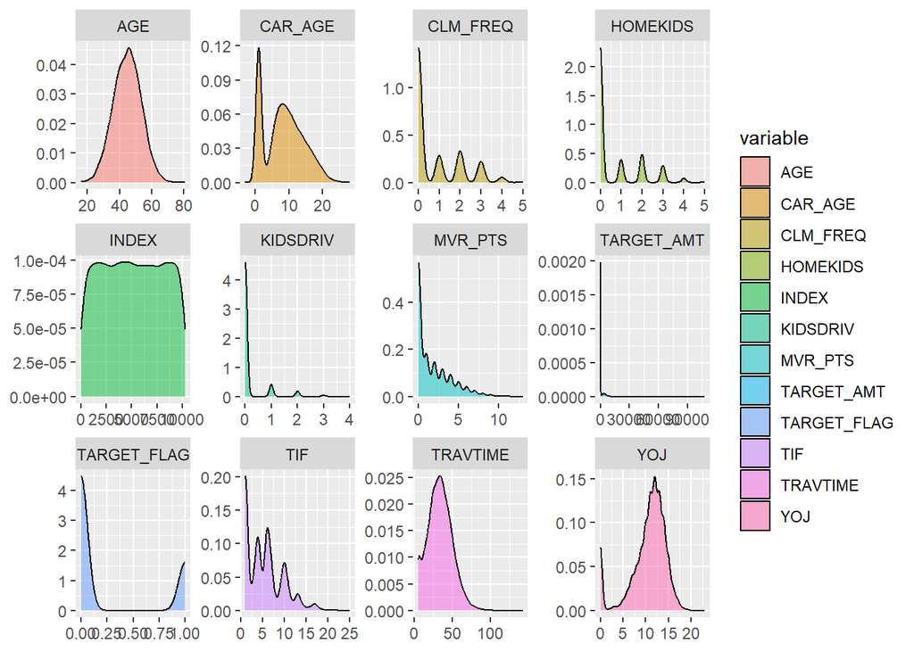

```r
ggplot(df_long, aes(x = value, fill = variable)) +
  geom_density(alpha = 0.5) +
  facet_wrap(~variable, scales ="free", ncol = 4) +
  labs(x = NULL, y = NULL)
```

Looking at the Target_Flag density plot, we see that the TARGET_FLAG plot is skewed to the right, indicating that there are more instances where cars weren’t in a crash compared to those where they were. This imbalance can lead to overfitting, where the model may become overly biased towards predicting the majority class (no crash).

To confirm lets see the proportion of 0’s to 1’s in the TARGET_FLAG column

```r
proportion_zeros <- sum(data_train$TARGET_FLAG == 0, na.rm = TRUE) / sum(!is.na(data_train$TARGET_FLAG)) * 100
proportion_ones <- 100 - proportion_zeros

cat("Proportion of 0s:", proportion_zeros, "%\n")
```

```
## Proportion of 0s: 73.61843 %
```

```r
cat("Proportion of 1s:", proportion_ones, "%\n")
```

```
## Proportion of 1s: 26.38157 %
```

This indicates that 73.6% or 6008 cars were not involved in a car crash while 26.4% or 2153 cars were. Since we have to predict the cost of the car crash let’s take a closer look at the TARGET_AMT variable. Let’s take out all the 6008 cars that were not involved in a crash and use the describe() from the psych package to look at the summary statistics of the cost.

```r
df_filtered <- data_train[data_train$TARGET_AMT != 0,]
describe(df_filtered$TARGET_AMT)
```

```
##    vars    n    mean      sd median trimmed    mad   min      max    range skew
## X1    1 2153 5702.18 7743.18   4104 4250.81 2317.3 30.28 107586.1 107555.9 5.63
##    kurtosis     se
## X1    42.45 166.88
```

There were 2153 cars involved in a crash. The mean cost of a car crash is $5702.18, the median is $4104 and the standard deviation is $7743.18. The cost ranged from $30.28 to $107586.10. This gives us a better sense of the distribution of the cost of car crashes. Since the mean is greater than the median, we can expect the distribution to be skewed to the right.

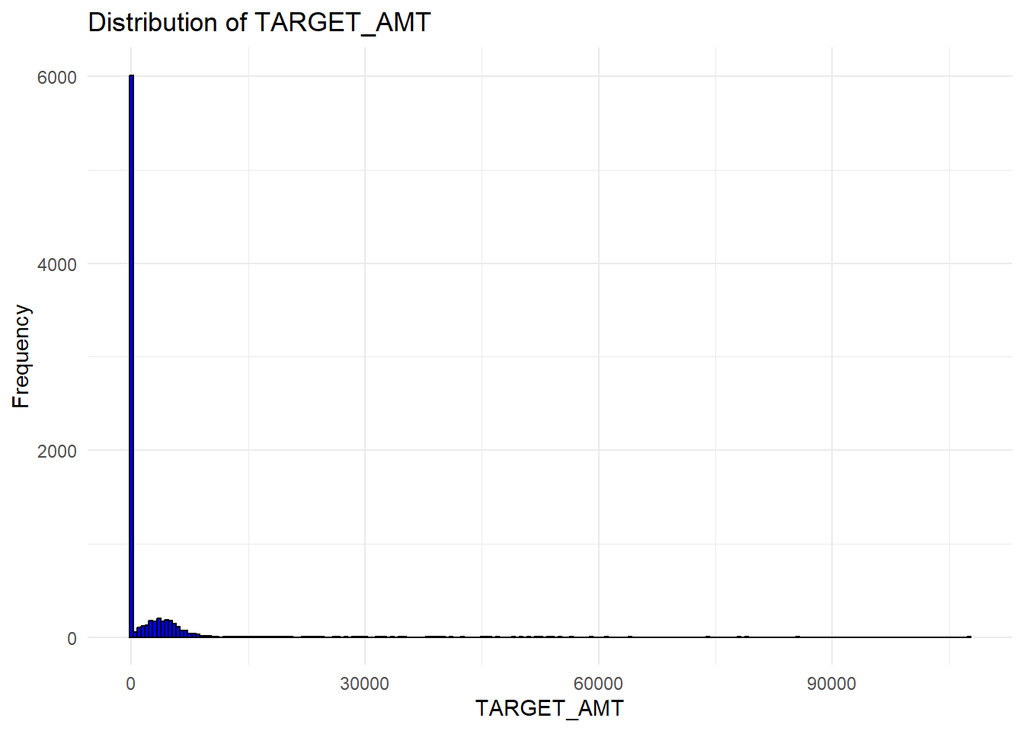

```r
ggplot(data_train, aes(x=TARGET_AMT)) +
  geom_histogram(binwidth=500, fill="blue", color="black") +
  theme_minimal() +
  labs(title="Distribution of TARGET_AMT", x="TARGET_AMT", y="Frequency")
```

#### Correlation plot

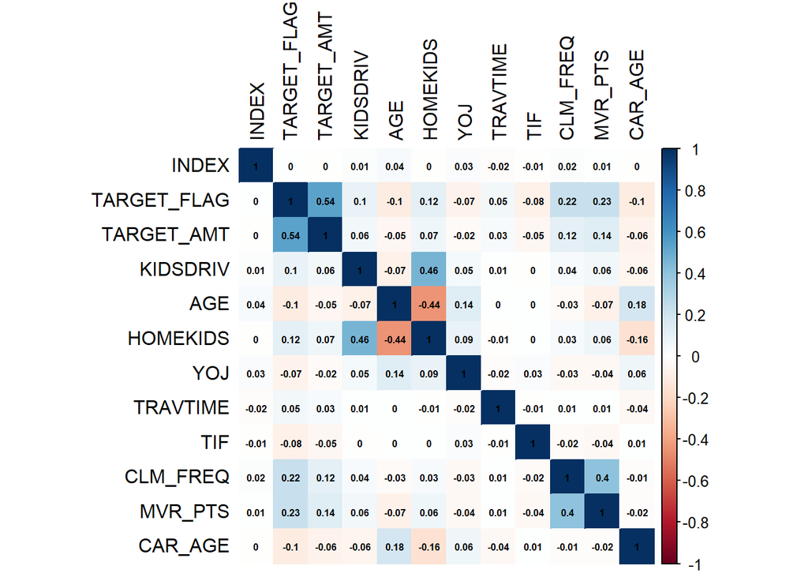

```r
numeric_data <- data_train %>%
  select_if(is.numeric)

correlation_matrix <- cor(numeric_data, use = "complete.obs")

corrplot(correlation_matrix, method = "color", tl.col = "black", addCoef.col = "black", number.cex = 0.5)
```

#### Box Plot

The box plot for the TARGET_AMT column also indicates a highly right-skewed distribution, despite the values ranging from 30 to 90 thousand. This skewness is evident from the compressed appearance of the box plot towards the lower end, suggesting the presence of outliers with exceptionally high values.

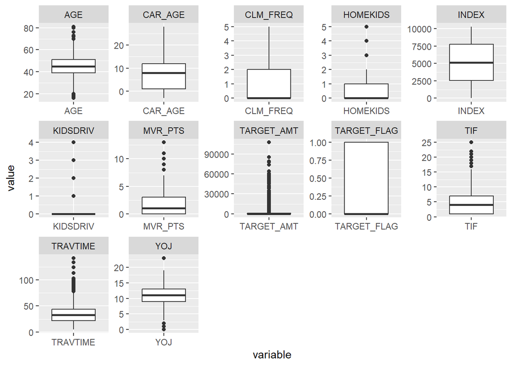

```r
df_long %>%
  ggplot(aes(variable, value)) +
  geom_boxplot() +
  facet_wrap(~variable, scales='free', ncol=5)
```

### Data Preperation

Out of the 8161 rows in the dataset, there were 6 rows in the AGE column where there was a missing value. Let’s remove rows where the AGE column is NA and also drop index column. The columns CAR_AGE and YOJ had NA values as well but we decided not to remove these rows as the NA values in these columns represented about 6% of the total rows. Removing 6% of the dataset would significantly impact the distribution of the data and our models.

```r
missing_values <- data_train %>%
  summarise_all(function(x) sum(is.na(x)))

print(missing_values)
```

```
##   INDEX TARGET_FLAG TARGET_AMT KIDSDRIV AGE HOMEKIDS YOJ INCOME PARENT1
## 1     0           0          0        0   6        0 454      0       0
##   HOME_VAL MSTATUS SEX EDUCATION JOB TRAVTIME CAR_USE BLUEBOOK TIF CAR_TYPE
## 1        0       0   0         0   0        0       0        0   0        0
##   RED_CAR OLDCLAIM CLM_FREQ REVOKED MVR_PTS CAR_AGE URBANICITY
## 1       0        0        0       0       0     510          0
```

```r
data_train <- data_train %>%
  filter(!is.na(AGE))

data_train <- subset(data_train, select = -INDEX)
```

Next, we removed the dollar sign from the OLDCLAIM, HOME_VAL, INCOME, and BLUEBOOK column. These are numeric values but were represented as strings in the dataset. These continuous variables may be important to the determining whether a car crashes and how much it cost.

```r
data_train$OLDCLAIM <- gsub("\\$|,", "", data_train$OLDCLAIM)
data_train$HOME_VAL <- gsub("\\$|,", "", data_train$HOME_VAL)
data_train$INCOME <- gsub("\\$|,", "", data_train$INCOME)
data_train$BLUEBOOK <- gsub("\\$|,", "", data_train$BLUEBOOK)
```

Converting the specified columns to numeric

```r
data_train$OLDCLAIM <- as.numeric(data_train$OLDCLAIM)
data_train$HOME_VAL <- as.numeric(data_train$HOME_VAL)
data_train$INCOME <- as.numeric(data_train$INCOME)
data_train$BLUEBOOK <- as.numeric(data_train$BLUEBOOK)

selected_vars <- data_train %>%
  dplyr::select(OLDCLAIM, HOME_VAL, INCOME, BLUEBOOK)

glimpse(selected_vars)
```

```
## Rows: 8,155
## Columns: 4
## $ OLDCLAIM <dbl> 4461, 0, 38690, 0, 19217, 0, 0, 2374, 0, 0, 0, 0, 5028, 0, 0,…
## $ HOME_VAL <dbl> 0, 257252, 124191, 306251, 243925, 0, NA, 333680, 0, 0, 0, 20…
## $ INCOME   <dbl> 67349, 91449, 16039, NA, 114986, 125301, 18755, 107961, 62978…
## $ BLUEBOOK <dbl> 14230, 14940, 4010, 15440, 18000, 17430, 8780, 16970, 11200, …
```

Some values seem to have invalid values, such as negative numbers, when that is so, we will replace with it with the median values. This will help maintain the distribution of the data.

```r
fix_missing <- function(df) {
  df %>%
    mutate_at(vars(c("CAR_AGE", "YOJ", "AGE", "INCOME", "HOME_VAL")), ~ifelse(. < 0, median(., na.rm = TRUE), .))
}

data_train <- fix_missing(data_train)
```

As mentioned before, let’s convert these categorical variables PARENT1, SEX, MSTATUS, CAR_USE, RED_CAR, REVOKED, URBANICITY into binary variables.

- `PARENT1` will be 1 if the observation was “YES”
- `SEX` will be 1 if the observation is “M”
- `STATUS` will be 1 if the observation is “Yes”
- `CAR_USE` will be 1 if the observation is “Private”
- `RED_CAR` will be 1 if the observation is “Yes
- `REVOKED` will be 1 if the observation is “Yes”
- `URBANICITY` will be 1 if the observation is “Urban”

```r
data_train <- data_train %>%
  mutate(PARENT1 = ifelse(PARENT1 == "Yes", 1, 0),
         SEX = ifelse(SEX == "M", 1, 0),
         MSTATUS = ifelse(MSTATUS == "Yes", 1, 0),
         CAR_USE = ifelse(CAR_USE == "Private", 1, 0),
         RED_CAR = ifelse(RED_CAR == "Yes", 1, 0),
         REVOKED = ifelse(REVOKED == "Yes", 1, 0),
         URBANICITY = ifelse(URBANICITY == "Urban", 1, 0))

print(colnames(data_train))
```

```
##  [1] "TARGET_FLAG" "TARGET_AMT"  "KIDSDRIV"    "AGE"         "HOMEKIDS"
##  [6] "YOJ"         "INCOME"      "PARENT1"     "HOME_VAL"    "MSTATUS"
## [11] "SEX"         "EDUCATION"   "JOB"         "TRAVTIME"    "CAR_USE"
## [16] "BLUEBOOK"    "TIF"         "CAR_TYPE"    "RED_CAR"     "OLDCLAIM"
## [21] "CLM_FREQ"    "REVOKED"     "MVR_PTS"     "CAR_AGE"     "URBANICITY"
```

```r
cate_var <- data_train %>%
  dplyr::select(PARENT1, SEX, MSTATUS, CAR_USE, RED_CAR, REVOKED, URBANICITY)

glimpse(cate_var)
```

```
## Rows: 8,155
## Columns: 7
## $ PARENT1    <dbl> 0, 0, 0, 0, 0, 1, 0, 0, 0, 0, 0, 0, 0, 0, 0, 1, 0, 0, 0, 0,…
## $ SEX        <dbl> 1, 1, 0, 1, 0, 0, 0, 1, 0, 1, 0, 0, 1, 1, 0, 0, 1, 0, 0, 0,…
## $ MSTATUS    <dbl> 0, 0, 1, 1, 1, 0, 1, 1, 0, 0, 0, 1, 1, 0, 1, 0, 1, 1, 1, 1,…
## $ CAR_USE    <dbl> 1, 0, 1, 1, 1, 0, 1, 0, 1, 0, 1, 1, 0, 0, 1, 1, 1, 1, 1, 0,…
## $ RED_CAR    <dbl> 0, 0, 0, 0, 0, 0, 0, 0, 0, 0, 0, 0, 0, 0, 0, 0, 0, 0, 0, 0,…
## $ REVOKED    <dbl> 0, 0, 0, 0, 1, 0, 0, 1, 0, 0, 0, 0, 1, 0, 0, 0, 0, 0, 0, 0,…
## $ URBANICITY <dbl> 0, 0, 0, 0, 0, 0, 0, 0, 0, 0, 0, 0, 0, 0, 0, 0, 0, 0, 0, 0,…
```

Since we are dealing with binary variables, using the pearson correlation would not be appropriate here as it only measures the linear relationship between two continuous variables. Instead we can use a chi-squared test to determine the association between two categorical variables. The table below measures the association of the variables we just converted to the binary response variable, TARGET_FLAG.

```r
variables <- c("PARENT1", "SEX", "MSTATUS", "CAR_USE", "RED_CAR", "REVOKED", "URBANICITY")

results <- data.frame(Variable = character(),
                      Chi_Squared = numeric(),
                      DF = integer(),
                      P_Value = numeric(),
                      stringsAsFactors = FALSE)

# Perform Chi-square test
for (var in variables) {
  contingency_table <- table(data_train[[var]], data_train$TARGET_FLAG)
  test_result <- chisq.test(contingency_table)

  results <- rbind(results, data.frame(Variable = var,
                                       Chi_Squared = test_result$statistic,
                                       DF = test_result$parameter,
                                       P_Value = test_result$p.value))
}

print(results)
```

```
##              Variable Chi_Squared DF      P_Value
## X-squared     PARENT1  197.321732  1 8.022490e-45
## X-squared1        SEX    3.515379  1 6.080175e-02
## X-squared2    MSTATUS  146.701710  1 9.118832e-34
## X-squared3    CAR_USE  166.431629  1 4.452272e-38
## X-squared4    RED_CAR 1826.104353  1 0.000000e+00
## X-squared5    REVOKED  187.056050  1 1.396232e-42
## X-squared6 URBANICITY 1826.104353  1 0.000000e+00
```

The table above shows that PARENT1, MSTATUS, CAR_USE, RED_CAR, REVOKED, and URBANICITY are statistically significant to TARGET_FLAG. SEX has a p-value of 0.0608 suggesting there is not a significant association between SEX and TARGET_FLAG.

Since we changed some columns to continuous variables, let’s do another correlation plot but with just the continuous variables.

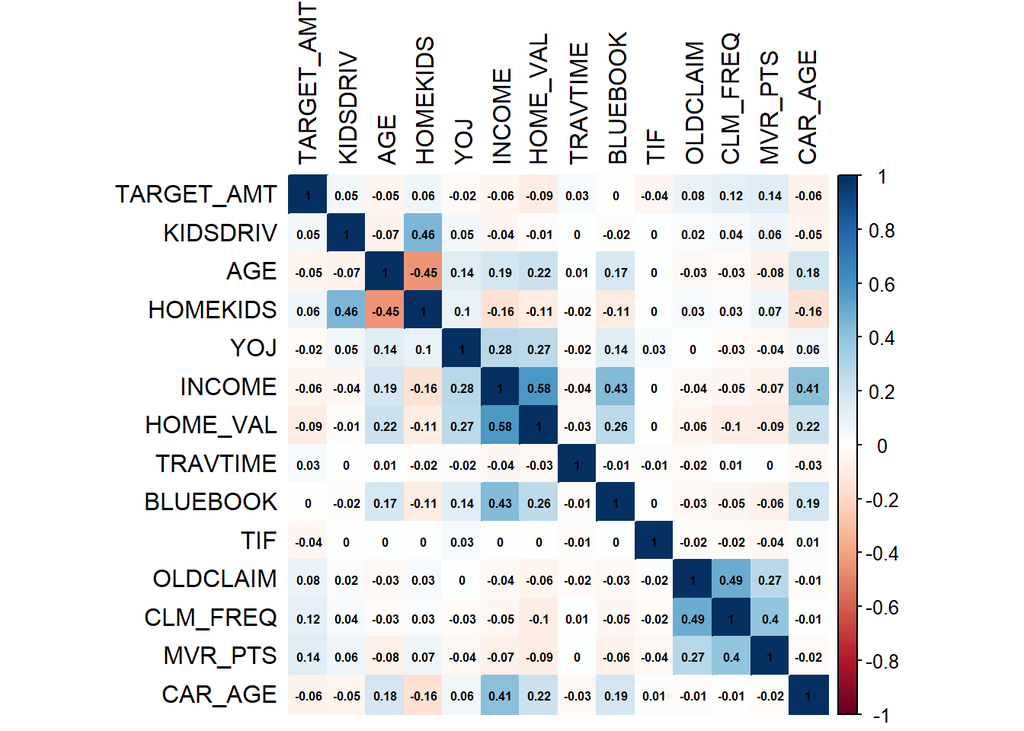

```r
# Identify continuous and binary variables
continuous_vars <- data_train %>%
  select_if(is.numeric) %>%
  select_if(~sum(. %in% 0:1) != length(.))

binary_vars <- data_train %>%
  select_if(is.numeric) %>%
  select_if(~sum(. %in% 0:1) == length(.))

# Compute correlation matrix for continuous variables
correlation_matrix <- cor(continuous_vars, use = "complete.obs")

# Create correlation plot
corrplot(correlation_matrix, method = "color", tl.col = "black", addCoef.col = "black", number.cex = 0.5)
```

There does not seem to be any predictors that have a strong linear correlation with TARGET_AMT. MVR_PTS (0.14), CLM_FREQ(0.12), and OLDCLAIM(0.08) seem to have the highest correlation among the continuous predictors.

### BUILD MODELS

#### Model 1

Let’s build a model using the variables CLM_FREQ, KIDSDRIV, CAR_AGE, and HOMEKIDS, as they showed higher correlations with the target variable during the correlation analysis.

```r
lm_model <- lm(TARGET_AMT ~ CLM_FREQ + KIDSDRIV + CAR_AGE + HOMEKIDS + MVR_PTS + AGE, data = data_train)

summary(lm_model)
```

```
##
## Call:
## lm(formula = TARGET_AMT ~ CLM_FREQ + KIDSDRIV + CAR_AGE + HOMEKIDS +
##     MVR_PTS + AGE, data = data_train)
##
## Residuals:
##    Min     1Q Median     3Q    Max
##  -4666  -1531   -967   -347 104154
##
## Coefficients:
##             Estimate Std. Error t value Pr(>|t|)
## (Intercept) 1323.146    346.233   3.822 0.000134 ***
## CLM_FREQ     305.630     50.522   6.049 1.52e-09 ***
## KIDSDRIV     272.054    121.071   2.247 0.024665 *
## CAR_AGE      -40.342      9.594  -4.205 2.64e-05 ***
## HOMEKIDS     123.105     61.243   2.010 0.044456 *
## MVR_PTS      228.105     27.337   8.344  < 2e-16 ***
## AGE           -5.563      7.082  -0.785 0.432198
## ---
## Signif. codes:  0 '***' 0.001 '**' 0.01 '*' 0.05 '.' 0.1 ' ' 1
##
## Residual standard error: 4689 on 7638 degrees of freedom
##   (510 observations deleted due to missingness)
## Multiple R-squared:  0.02962,    Adjusted R-squared:  0.02885
## F-statistic: 38.85 on 6 and 7638 DF,  p-value: < 2.2e-16
```

Now let’s do a stepwise model where the algorithm chooses the best subset of predictors based on a specified criterion, such as the Akaike Information Criterion (AIC) or Bayesian Information Criterion (BIC).

```r
stepwise_model <- step(lm_model, direction = "both", trace = 0)

summary(stepwise_model)
```

```
##
## Call:
## lm(formula = TARGET_AMT ~ CLM_FREQ + KIDSDRIV + CAR_AGE + HOMEKIDS +
##     MVR_PTS, data = data_train)
##
## Residuals:
##    Min     1Q Median     3Q    Max
##  -4792  -1530   -966   -365 104122
##
## Coefficients:
##             Estimate Std. Error t value Pr(>|t|)
## (Intercept) 1066.845    115.778   9.215  < 2e-16 ***
## CLM_FREQ     305.445     50.521   6.046 1.56e-09 ***
## KIDSDRIV     256.425    119.422   2.147  0.03181 *
## CAR_AGE      -41.256      9.523  -4.332 1.49e-05 ***
## HOMEKIDS     144.599     54.788   2.639  0.00833 **
## MVR_PTS      229.269     27.296   8.399  < 2e-16 ***
## ---
## Signif. codes:  0 '***' 0.001 '**' 0.01 '*' 0.05 '.' 0.1 ' ' 1
##
## Residual standard error: 4689 on 7639 degrees of freedom
##   (510 observations deleted due to missingness)
## Multiple R-squared:  0.02954,    Adjusted R-squared:  0.0289
## F-statistic:  46.5 on 5 and 7639 DF,  p-value: < 2.2e-16
```

lm_model (with AGE, Model 1):

#### Model 2

```r
model2 <- glm(TARGET_FLAG ~ CLM_FREQ + MVR_PTS + KIDSDRIV + MSTATUS + CAR_USE  + REVOKED,
             data = data_train, family = binomial)

summary(model2)
```

```
##
## Call:
## glm(formula = TARGET_FLAG ~ CLM_FREQ + MVR_PTS + KIDSDRIV + MSTATUS +
##     CAR_USE + REVOKED, family = binomial, data = data_train)
##
## Coefficients:
##             Estimate Std. Error z value Pr(>|z|)
## (Intercept) -1.06125    0.05928 -17.902   <2e-16 ***
## CLM_FREQ     0.26489    0.02336  11.341   <2e-16 ***
## MVR_PTS      0.14644    0.01260  11.624   <2e-16 ***
## KIDSDRIV     0.40433    0.04795   8.432   <2e-16 ***
## MSTATUS     -0.58283    0.05401 -10.790   <2e-16 ***
## CAR_USE     -0.60461    0.05420 -11.155   <2e-16 ***
## REVOKED      0.85418    0.07392  11.555   <2e-16 ***
## ---
## Signif. codes:  0 '***' 0.001 '**' 0.01 '*' 0.05 '.' 0.1 ' ' 1
##
## (Dispersion parameter for binomial family taken to be 1)
##
##     Null deviance: 9404.0  on 8154  degrees of freedom
## Residual deviance: 8432.7  on 8148  degrees of freedom
## AIC: 8446.7
##
## Number of Fisher Scoring iterations: 4
```

This model shows that all the predictor variables are statistically significant. The AIC for the model is 8446.7. Next, let’s use the stepAIC function to improve this model.

```r
step_model <- stepAIC(model2, direction = "both", trace = FALSE)
summary(step_model)
```

```
##
## Call:
## glm(formula = TARGET_FLAG ~ CLM_FREQ + MVR_PTS + KIDSDRIV + MSTATUS +
##     CAR_USE + REVOKED, family = binomial, data = data_train)
##
## Coefficients:
##             Estimate Std. Error z value Pr(>|z|)
## (Intercept) -1.06125    0.05928 -17.902   <2e-16 ***
## CLM_FREQ     0.26489    0.02336  11.341   <2e-16 ***
## MVR_PTS      0.14644    0.01260  11.624   <2e-16 ***
## KIDSDRIV     0.40433    0.04795   8.432   <2e-16 ***
## MSTATUS     -0.58283    0.05401 -10.790   <2e-16 ***
## CAR_USE     -0.60461    0.05420 -11.155   <2e-16 ***
## REVOKED      0.85418    0.07392  11.555   <2e-16 ***
## ---
## Signif. codes:  0 '***' 0.001 '**' 0.01 '*' 0.05 '.' 0.1 ' ' 1
##
## (Dispersion parameter for binomial family taken to be 1)
##
##     Null deviance: 9404.0  on 8154  degrees of freedom
## Residual deviance: 8432.7  on 8148  degrees of freedom
## AIC: 8446.7
##
## Number of Fisher Scoring iterations: 4
```

Next, let’s create a multiple linear regression model to predict the amount of money it will cost if the person does crash their car. We will use the same predictors as before with the binary model since they were all statistically significant in predicting TARGET_FLAG.

```r
model2_linear <- lm(TARGET_AMT ~ CLM_FREQ + MVR_PTS + KIDSDRIV + MSTATUS + CAR_USE + REVOKED, data = data_train)

summary(model2_linear)
```

```
##
## Call:
## lm(formula = TARGET_AMT ~ CLM_FREQ + MVR_PTS + KIDSDRIV + MSTATUS +
##     CAR_USE + REVOKED, data = data_train)
##
## Residuals:
##    Min     1Q Median     3Q    Max
##  -5082  -1657   -917   -179 104324
##
## Coefficients:
##             Estimate Std. Error t value Pr(>|t|)
## (Intercept)  1740.83     119.76  14.536  < 2e-16 ***
## CLM_FREQ      246.90      48.21   5.122 3.10e-07 ***
## MVR_PTS       216.90      25.98   8.350  < 2e-16 ***
## KIDSDRIV      451.31     100.09   4.509 6.60e-06 ***
## MSTATUS      -737.74     104.65  -7.049 1.94e-12 ***
## CAR_USE      -824.24     106.08  -7.770 8.80e-15 ***
## REVOKED       660.78     156.23   4.229 2.37e-05 ***
## ---
## Signif. codes:  0 '***' 0.001 '**' 0.01 '*' 0.05 '.' 0.1 ' ' 1
##
## Residual standard error: 4609 on 8148 degrees of freedom
## Multiple R-squared:  0.04134,    Adjusted R-squared:  0.04064
## F-statistic: 58.56 on 6 and 8148 DF,  p-value: < 2.2e-16
```

Like the binary model, all of the coefficients in this multiple linear regression model have a p-value less than 0.05, indicating they are statistically significant. The intercept is 1740.8, which means that when all predictor variables are zero the expect cost of a car crash is $1740.8. When MSTATUS and CAR_USE changes from 0 to 1, this causes a decrease of 737.74 and 824.24 in cost of the car crash. This makes sense as married people generally drive safer and private vehicles are not driven as often as commercial vehicles. All of the other coefficients drive the cost of car crashes up with a one unit increase.

Overall, the p-value for the model is less than 0.05, indicating it is statistically significant in predicting TARGET_AMT. However, the R-squared for this model is 0.04134, suggesting that only 4% of the variability in TARGET_AMT can be explained by the model. Although this is very low, it is higher than the R-squared of the first model(0.02). Therefore, it may be advisable to retain the model for further analysis and refinement.